# Linear Regression, Principal Component Regression, Lasso & Stepwise

Brendan Mapes

10/7/2021

*Investigating for multicollinearity.*

```r
library(MASS)
library(car)
boston <- Boston
lm1 <- lm(boston$medv ~ boston$crim + boston$zn + boston$indus + boston$nox + boston$rm + boston$age + boston$tax, data = boston)
summary(lm1)
```

```
##
## Call:
## lm(formula = boston$medv ~ boston$crim + boston$zn + boston$indus +
##     boston$nox + boston$rm + boston$age + boston$tax, data = boston)
##
## Residuals:
##     Min      1Q  Median      3Q     Max
## -16.625  -3.161  -0.833   2.089  41.042
##
## Coefficients:
##                Estimate Std. Error t value Pr(>|t|)
## (Intercept)  -19.615259   3.221482  -6.089 2.27e-09 ***
## boston$crim   -0.132538   0.038482  -3.444 0.000621 ***
## boston$zn      0.022103   0.014823   1.491 0.136547
## boston$indus  -0.014980   0.072282  -0.207 0.835909
## boston$nox     0.010643   4.230468   0.003 0.997994
## boston$rm      7.606508   0.418424  18.179  < 2e-16 ***
## boston$age    -0.023198   0.014893  -1.558 0.119964
## boston$tax    -0.009006   0.002662  -3.384 0.000772 ***
## ---
## Signif. codes:  0 '***' 0.001 '**' 0.01 '*' 0.05 '.' 0.1 ' ' 1
##
## Residual standard error: 5.989 on 498 degrees of freedom
## Multiple R-squared:  0.5818, Adjusted R-squared:  0.576
## F-statistic: 98.99 on 7 and 498 DF,  p-value: < 2.2e-16
```

```r
x_vars <- boston[, c(1,2,3,5,6,7,10)]
cor(x_vars)
```

```
##             crim         zn      indus        nox         rm        age
## crim   1.0000000 -0.2004692  0.4065834  0.4209717 -0.2192467  0.3527343
## zn    -0.2004692  1.0000000 -0.5338282 -0.5166037  0.3119906 -0.5695373
## indus  0.4065834 -0.5338282  1.0000000  0.7636514 -0.3916759  0.6447785
## nox    0.4209717 -0.5166037  0.7636514  1.0000000 -0.3021882  0.7314701
## rm    -0.2192467  0.3119906 -0.3916759 -0.3021882  1.0000000 -0.2402649
## age    0.3527343 -0.5695373  0.6447785  0.7314701 -0.2402649  1.0000000
## tax    0.5827643 -0.3145633  0.7207602  0.6680232 -0.2920478  0.5064556
##              tax
## crim   0.5827643
## zn    -0.3145633
## indus  0.7207602
## nox    0.6680232
## rm    -0.2920478
## age    0.5064556
## tax    1.0000000
```

```r
vif(lm1)
```

```
##  boston$crim    boston$zn boston$indus   boston$nox    boston$rm   boston$age
##     1.542630     1.682654     3.462196     3.383524     1.216923     2.474575
##   boston$tax
##     2.833196
```

Based off variance inflation factor calculation by the VIF function from the car package in R, it doesn’t appear multicollinearity is confusing the results for any of the available predictor variables. If VIF were exceptionally large for any of the included variables, removing it from the model may solve the issue. Otherwise, principal component regression or ridge regression should be utilized instead of multiple linear regression.

*Compare results of linear regression and Principal Component Regression to predict ‘medv’ based on the available variables.*

```r
library(pls)
set.seed(1234)
pcr_version <- pcr(boston$medv ~ boston$crim + boston$zn + boston$indus + boston$nox + boston$rm + boston$age + boston$tax, data = boston, scale = TRUE, validation = "CV")
summary(pcr_version)
```

```
## Data:    X dimension: 506 7
##  Y dimension: 506 1
## Fit method: svdpc
## Number of components considered: 7
##
## VALIDATION: RMSEP
## Cross-validated using 10 random segments.
##        (Intercept)  1 comps  2 comps  3 comps  4 comps  5 comps  6 comps
## CV           9.206    7.436    7.419    6.055    6.063    6.046    6.030
## adjCV        9.206    7.435    7.425    6.050    6.059    6.042    6.026
##        7 comps
## CV       6.032
## adjCV    6.027
##
## TRAINING: % variance explained
##              1 comps  2 comps  3 comps  4 comps  5 comps  6 comps  7 comps
## X              55.53    69.11    81.10    88.61    94.00    97.15   100.00
## boston$medv    34.72    34.87    57.42    57.45    57.75    58.03    58.18
```

```r
summary(lm1)
```

```
##
## Call:
## lm(formula = boston$medv ~ boston$crim + boston$zn + boston$indus +
##     boston$nox + boston$rm + boston$age + boston$tax, data = boston)
##
## Residuals:
##     Min      1Q  Median      3Q     Max
## -16.625  -3.161  -0.833   2.089  41.042
##
## Coefficients:
##                Estimate Std. Error t value Pr(>|t|)
## (Intercept)  -19.615259   3.221482  -6.089 2.27e-09 ***
## boston$crim   -0.132538   0.038482  -3.444 0.000621 ***
## boston$zn      0.022103   0.014823   1.491 0.136547
## boston$indus  -0.014980   0.072282  -0.207 0.835909
## boston$nox     0.010643   4.230468   0.003 0.997994
## boston$rm      7.606508   0.418424  18.179  < 2e-16 ***
## boston$age    -0.023198   0.014893  -1.558 0.119964
## boston$tax    -0.009006   0.002662  -3.384 0.000772 ***
## ---
## Signif. codes:  0 '***' 0.001 '**' 0.01 '*' 0.05 '.' 0.1 ' ' 1
##
## Residual standard error: 5.989 on 498 degrees of freedom
## Multiple R-squared:  0.5818, Adjusted R-squared:  0.576
## F-statistic: 98.99 on 7 and 498 DF,  p-value: < 2.2e-16
```

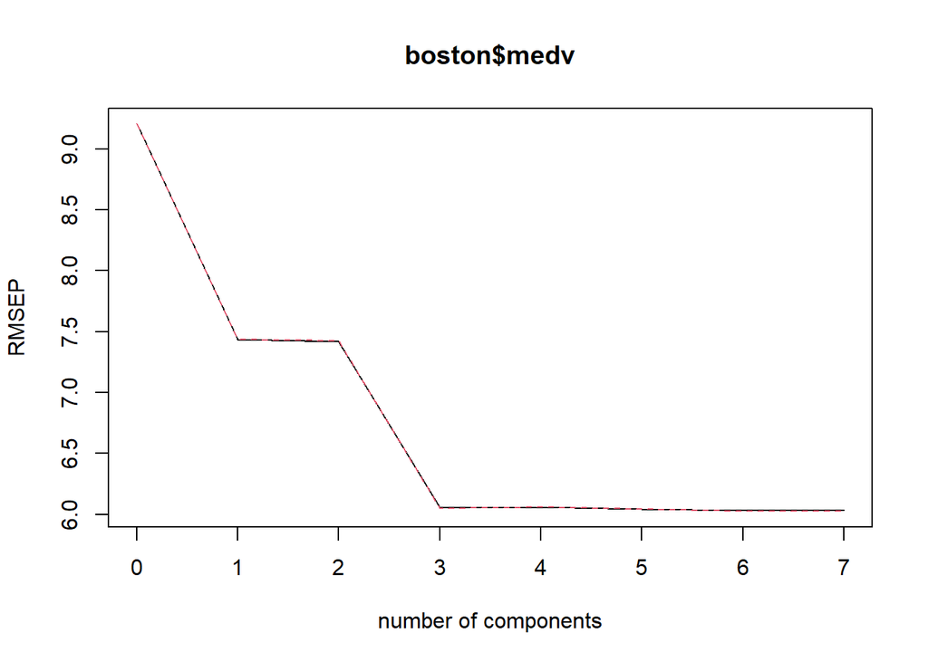

```r
validationplot(pcr_version)
```

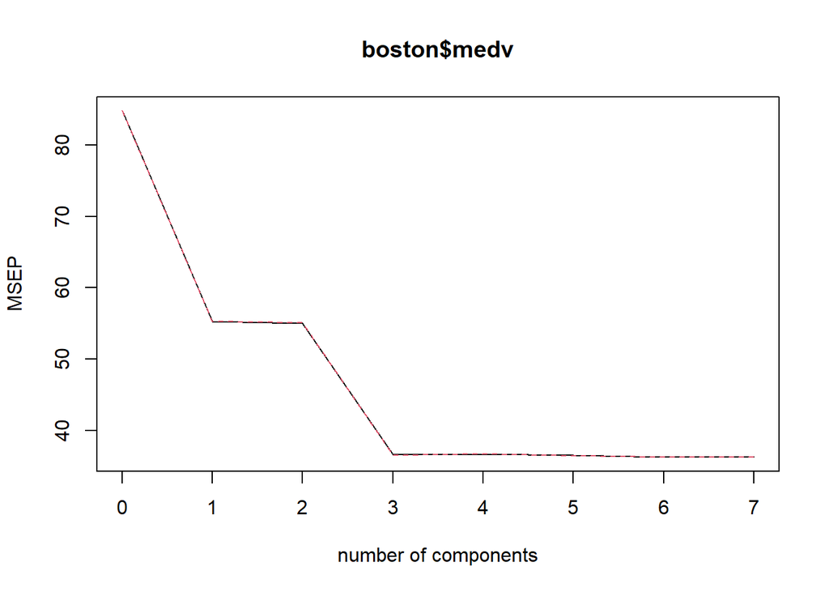

```r
validationplot(pcr_version, val.type="MSEP")
```

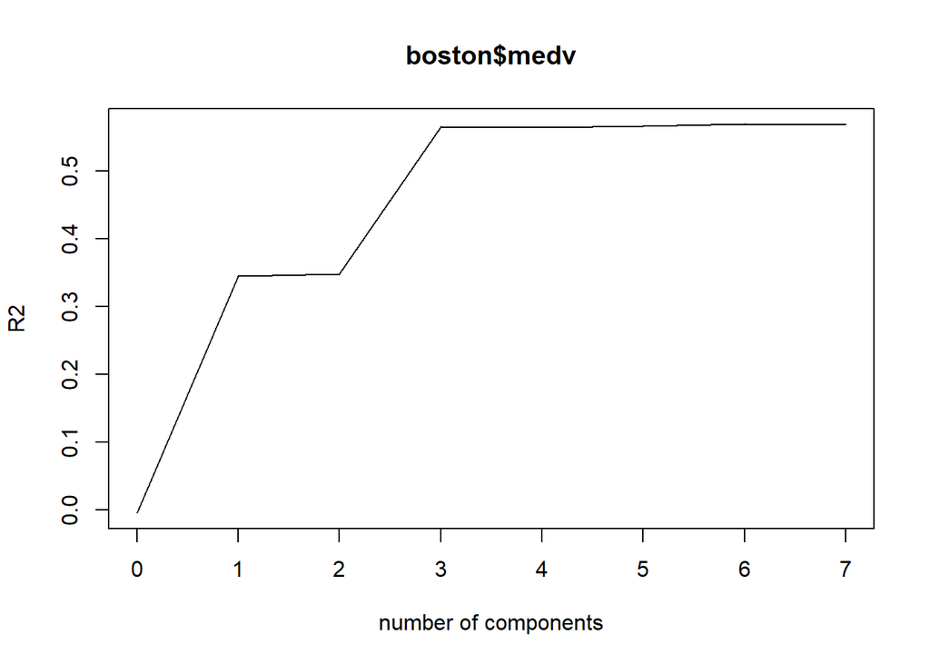

```r
validationplot(pcr_version, val.type="R2")
```

PCR results suggest that 3 components dominate this model. However, in reality, PCR is likely not necessary here, as results to the first problem suggested multicollinearity wasn’t an issue in this example. To complete PCR modeling, data could be split into training and test data before running the pcr function, then the pcr function could be used again to predict on the test set, with the number of components suggested to be dominating the model, 3 in this case. That computation is inlcuded below. And high RSME suggests PCR hasn’t improved the model. Note: This method follows roughly the outlined method published at https://www.r-bloggers.com/2016/07/performing-principal-components-regression-pcr-in-r/#:~:text=Performing%20Principal%20Components%20Regression%20%28PCR%29%20in%20R%201,5%20Performing%20PCR%20on%20a%20test%20dataset.%20.

```r
training <- boston[1:400,]
y_test <- boston[401:500, 14]
test <- boston[401:500, 1:13]

pcr <- pcr(training$medv ~ training$crim + training$zn + training$indus + training$nox + training$rm + training$age + training$tax, data = training, scale = TRUE, validation = "CV")

prediction <- predict(pcr, test, ncomp = 3)
mean((prediction - y_test)^2)
```

```
## [1] 153.1227
```

*Comparing models selected using lasso vs a stepwise procedure to predict ‘medv’ using all available variables.*

## Lasso

```r
library(glmnet)
x_var <- model.matrix(boston$medv ~ boston$crim + boston$zn + boston$indus + boston$nox + boston$rm + boston$age + boston$tax)[,-1]
y_var <- boston$medv
lambda <- 10^seq(2,-2, by=-.1)


#split train and test
train_b = sample(1:nrow(x_var), nrow(x_var)/2)
x_test = (-train_b)
y_test = y_var[x_test]

cv <- cv.glmnet(x_var[train_b,], y_var[train_b], alpha = 1, lambda = lambda, nfolds = 5)

#optimal lambda
lambda_optimal <- cv$lambda.min
lambda_optimal
```

```
## [1] 0.1584893
```

```r
final_model <- glmnet(x_var[train_b,],y_var[train_b], alpha=1, lambda=lambda_optimal)
prediction_b <- predict(final_model, s=lambda_optimal, newx=x_var[x_test,])


coef(final_model)
```

```
## 8 x 1 sparse Matrix of class "dgCMatrix"
##                         s0
## (Intercept)  -14.256448697
## boston$crim   -0.103528805
## boston$zn      0.007981946
## boston$indus  -0.098565391
## boston$nox     .
## boston$rm      6.836300569
## boston$age    -0.027486981
## boston$tax    -0.008031411
```

## Forward stepwise

```r
library(stats)

intercept_only <- lm(boston$medv ~ 1, data = boston)

all_predictors <- lm(boston$medv~boston$crim + boston$zn + boston$indus + boston$nox + boston$rm + boston$age + boston$tax, data=boston)

forward_step <- step(intercept_only, direction='forward', scope=formula(all_predictors), trace=0)

forward_step$anova
```

```
##            Step Df    Deviance Resid. Df Resid. Dev      AIC
## 1               NA          NA       505   42716.30 2246.514
## 2   + boston$rm -1 20654.41622       504   22061.88 1914.185
## 3  + boston$tax -1  3290.79855       503   18771.08 1834.449
## 4 + boston$crim -1   472.60990       502   18298.47 1823.546
## 5  + boston$age -1   341.94714       501   17956.52 1816.001
## 6   + boston$zn -1    92.89492       500   17863.63 1815.377
```

```r
coef(forward_step)
```

```
##   (Intercept)     boston$rm    boston$tax   boston$crim    boston$age
## -19.713176207   7.625252520  -0.009323412  -0.131851739  -0.024120898
##     boston$zn
##   0.022946814
```

*Comparing the various procedures.Rate the performance of procedures:1 = Good, 2 = Fair, 3 = Poor.*

1. Performance when p >> n
   - OLS: 3
   - Ridge: 2
   - Lasso: 1
   - Elastic Net: 1
2. Performance under multicollinearity
   - OLS: 3
   - Ridge: 1
   - Lasso: 2
   - Elastic Net: 1
3. Unbiased Estimation
   - OLS: 1
   - Ridge: 2
   - Lasso: 3
   - Elastic Net: 2
4. Model Selection
   - OLS: 3
   - Ridge: 2
   - Lasso: 1
   - Elastic net: 1
5. Simplicity, Computation, Inference, Interpretation
   - OLS: 1
   - Ridge: 2
   - Lasso: 2
   - Elastic Net: 3